# pep2 boots

2024-12-30

# Pregunta 1

Para responder esta pregunta, se pide reaizar un análisis inferencial usando remuestreo con permutaciones (100 repeticiones) y 95% de confianza, explicando y justificando paso a paso el procedimiento seguido, incluyendo las hiótesis contrastadas y la interpretación de los resultados obtenidos para la pregunta del Gobierno.

## Respuesta

```r
# Leemos los datos
datos <- read.csv("EI-2024-2-PE2-Datos-Forma-06.csv")
datos$macro_zona <- as.factor(datos$macro_zona)
datos$franja <- as.factor(datos$franja)

str(datos)
```

```
## 'data.frame':    100 obs. of  13 variables:
##  $ macro_zona: Factor w/ 3 levels "centro","norte",..: 3 1 2 3 3 2 2 3 2 1 ...
##  $ franja    : Factor w/ 3 levels "cordillera","costa",..: 3 2 1 3 1 2 2 3 1 3 ...
##  $ temp_ver  : num  24 20.4 24.3 24.1 20.8 25 23.4 25.5 25.1 29.6 ...
##  $ temp_inv  : num  4.4 8.4 2.3 1.8 2.7 12 12.2 4.1 2.1 4 ...
##  $ superf    : num  109 91.3 117.2 48 198.6 ...
##  $ res_term  : num  1.09 0.68 1.16 0.64 1.82 0.86 0.5 0.72 1.17 0.93 ...
##  $ n_elec_gr : int  3 2 3 2 5 3 2 2 3 2 ...
##  $ edad_elec : num  6.1 5.5 5.3 8.1 3.5 3 7.7 17.2 8.2 3.2 ...
##  $ n_ocup    : int  4 5 5 1 5 5 4 3 4 2 ...
##  $ ing_fam   : int  1032 1008 1341 264 1693 1162 1127 860 1392 946 ...
##  $ horas_uso : num  47.5 35.9 51.7 30 87.4 50.8 33.4 32.1 43.4 31.8 ...
##  $ consumo   : num  9.7 7 10.2 8.3 14.6 6.9 6.7 9 10.5 8.8 ...
##  $ sobre_cons: chr  "si" "no" "si" "no" ...
```

```r
set.seed(131)
```

### Planteamiento de hipótesis:

H0: La proporción de viviendas DFL2 que pagan el “cargo por sobreconsumo” en la macrozona centro es igual a la proporción en la macrozona sur. Ha: La proporción de viviendas DFL2 que pagan el “cargo por sobreconsumo” en la macrozona centro es diferente a la proporción en la macrozona sur.

H0: p_centro = p_sur Ha: p_centro != p_sur

Siendo p_centro y p_sur las proporciones de viviendas DFL2 que pagan el “cargo por sobreconsumo” en la macrozona centro y sur, respectivamente.

Para contrastar estas hipótesis en base a lo que dice el enunciado utilizaremos un nivel de confianza del 95%.

Obtenemos los datos relevantes:

```r
# Filtrar viviendas DFL2 (superficie <= 120 m2)
data_DFL2 <- subset(datos, superf <= 120)

# Separar datos por macrozona (centro y sur)
centro <- subset(data_DFL2, macro_zona == "centro")
sur <- subset(data_DFL2, macro_zona == "sur")
```

### Estadístico de prueba:

El estadístico a utilizar para docimar las hipótesis propuestas es la diferencia en proporciones de sobreconsumo entre la macrozona centro y sur, ya que es el más relevante en base a lo que estamos buscando.

```r
# Calcular proporción de sobreconsumo en cada macrozona
prop_centro <- mean(centro$sobre_cons == "si")
prop_sur <- mean(sur$sobre_cons == "si")

# Diferencia observada en proporciones
diff_obs <- prop_centro - prop_sur

cat("Diferencia observada en proporciones:", diff_obs, "\n")
```

```
## Diferencia observada en proporciones: 0.09454545
```

### Remuestreo

A continuación, realizamos el análisis inferencial mediante remuestreo con permutaciones:

Combinamos los datos de ambas macrozonas:

```r
# Crear la columna combinada para remuestreo
data_combined <- data_DFL2[, c("macro_zona", "sobre_cons")]
```

Realizamos las 100 permutaciones:

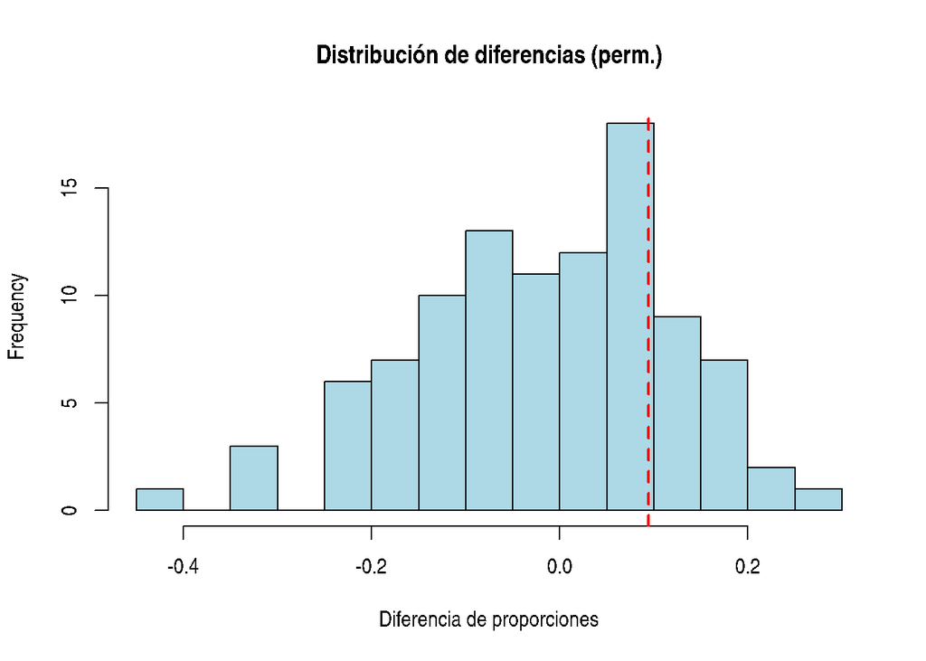

```r
perm_test <- function(data, n_perm = 100) {
  diff_perm <- numeric(n_perm)

  for (i in 1:n_perm) {
    # Permutar las etiquetas de macrozona
    data$macro_zona <- sample(data$macro_zona)

    # Recalcular proporciones con las etiquetas permutadas
    prop_centro_perm <- mean(data[data$macro_zona == "centro", "sobre_cons"] == "si")
    prop_sur_perm <- mean(data[data$macro_zona == "sur", "sobre_cons"] == "si")

    # Guardar la diferencia en proporciones
    diff_perm[i] <- prop_centro_perm - prop_sur_perm
  }

  return(diff_perm)
}

# Ejecutar 100 permutaciones
n_permutations <- 100
diff_permuted <- perm_test(data_combined, n_perm = n_permutations)

# Crear un histograma para la distribución de diferencias permutadas
hist(diff_permuted, breaks = 20, main = "Distribución de diferencias (perm.)",
     xlab = "Diferencia de proporciones", col = "lightblue")
abline(v = diff_obs, col = "red", lwd = 2, lty = 2)  # Línea para la diferencia observada
```

Ahora con las permutaciones realizadas, calculamos el p-value para contrastar las hipótesis:

```r
p_value <- mean(abs(diff_permuted) >= abs(diff_obs))

cat("P-valor:", p_value, "\n")
```

```
## P-valor: 0.53
```

Como vemos, obtenemos un p-value de 0.53, como estamos utilizando un intervalo de confianza del 95%, y el p-value es mayor a 0.05, no podemos rechazar la hipótesis nula. Por lo tanto, no hay evidencia suficiente para afirmar que la proporción de viviendas DFL2 que pagan el “cargo por sobreconsumo” en la macrozona centro es diferente a la proporción en la macrozona sur.